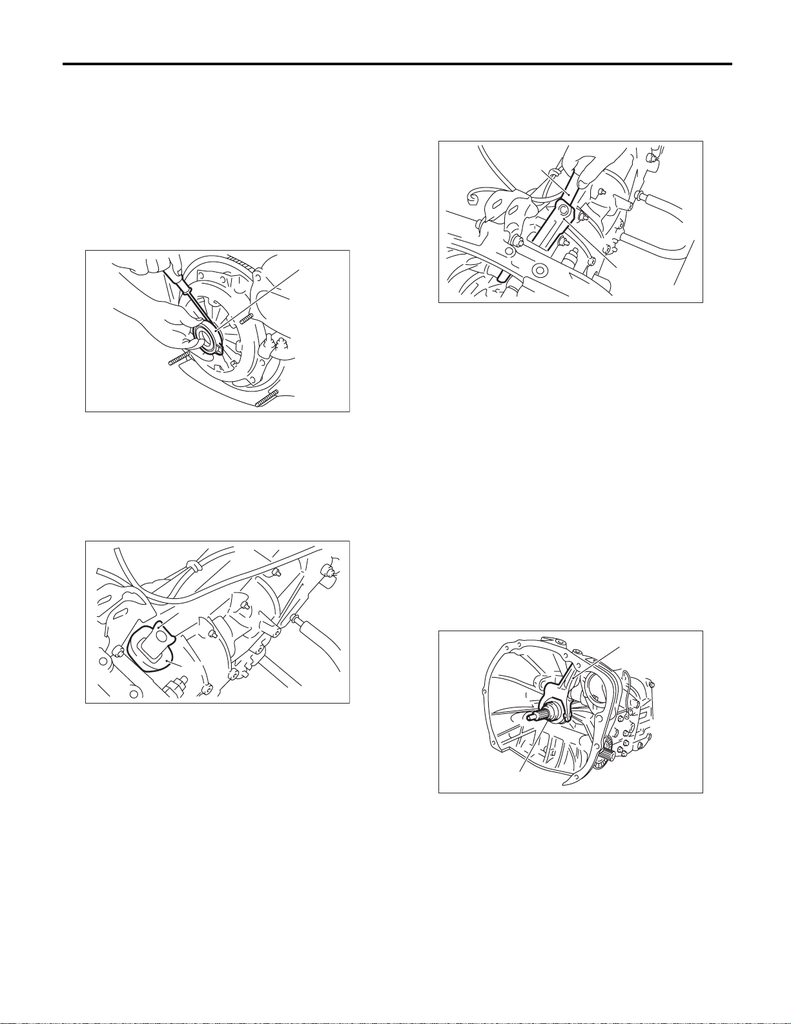

CL-17

Release Bearing and Lever

CLUTCH SYSTEM

4. Release Bearing and Lever

A: REMOVAL

1. STI MODEL

1) Remove the transmission assembly from the ve-

hicle. <Ref. to 6MT(TY85)-31, REMOVAL, Manual

Transmission Assembly.>

2) Remove the release lever from the transmission.

3) Using a flat tip screwdriver, remove the release

bearing from the clutch cover.

2. EXCEPT FOR STI MODEL

1) Remove the transmission assembly from the ve-

hicle. <Ref. to 6MT(TY75)-25, REMOVAL, Manual

Transmission Assembly.>

2) Remove the dust cover.

3) Remove the lever spring from the pivot with a

screwdriver by accessing it through the clutch

housing release lever hole. Then remove the re-

lease lever and release bearing as a unit.

B: INSTALLATION

1. STI MODEL

NOTE:

Apply the specified grease to lubricate to the follow-

ing points before installation.

• Release lever shaft

• Contact surface of release lever and bearing

• Transmission main shaft spline

• Contact surface of release bearing and clutch re-

lease bearing guide

Grease:

NICHIMOLY N-130 or equivalent

1) Attach the release bearing to the transmission.

2) Insert the release lever into the release bearing

tab.

(A) Release bearing

(A) Release lever

(B) Dust cover

CL-00025

(A)

CL-00023

(A)

(B)

(A) Release lever

(B) Screwdriver

(A) Release lever

(B) Release bearing

CL-00024

(B)

(A)

CL-00028

(A)

(B)

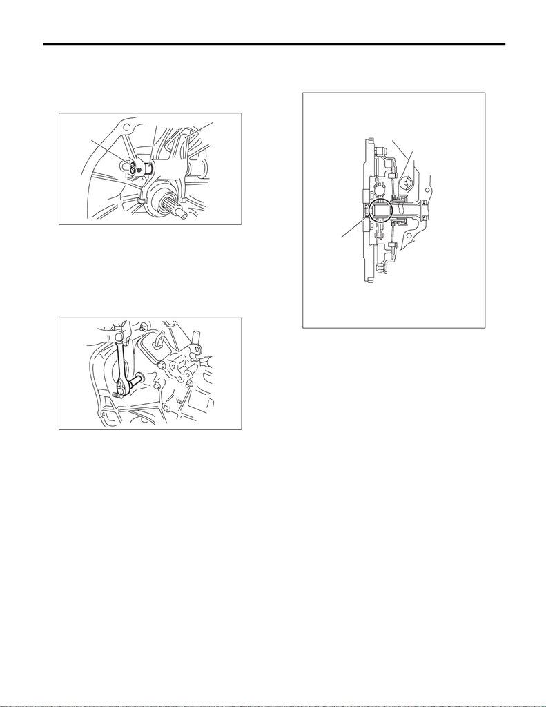

CL-18

Release Bearing and Lever

CLUTCH SYSTEM

3) Insert the release lever shaft into the release le-

ver.

NOTE:

Make sure the cut portion of the release lever shaft

comes into contact with the spring pin.

4) Tighten the plugs.

Tightening torque:

48 N·m (4.9 kgf-m, 35.4 ft-lb)

5) Check the bearing for smooth movement by op-

erating the release lever.

6) Apply grease to the contact surface of the re-

lease lever and operating cylinder.

Grease:

NICHIMOLY N-130 or equivalent

7) Apply grease to splines.

Grease:

NICHIMOLY N-130 or equivalent

8) Install the transmission assembly. <Ref. to

6MT(TY85)-33, INSTALLATION, Manual Trans-

mission Assembly.>

(A) Release lever

(B) Release lever shaft

(C) Spring pin

CL-00030

(A)

(B)

(C)

CL-00031

(A) Spline

CL-00341

(A)

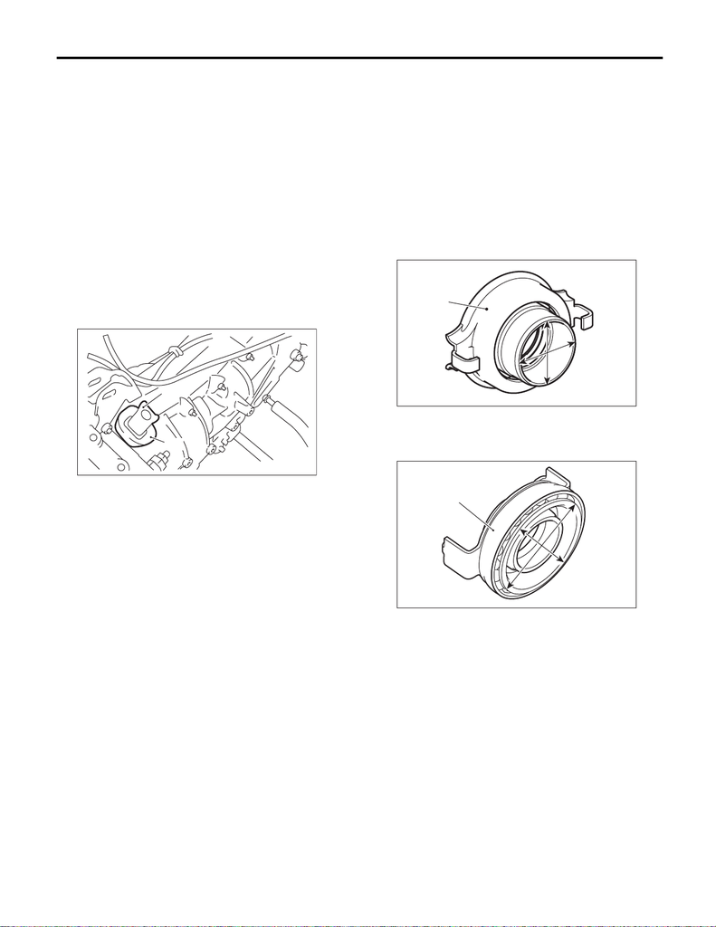

CL-19

Release Bearing and Lever

CLUTCH SYSTEM

2. EXCEPT FOR STI MODEL

NOTE:

Apply the specified grease to lubricate to the follow-

ing points before installation.

• Contact surface of lever and pivot

• Contact surface of lever and bearing

• Transmission main shaft spline

• Contact surface of release bearing and transmis-

sion case

Grease:

NICHIMOLY N-130 or equivalent

1) Install the release bearing by inserting the re-

lease lever into the clutch housing release lever

hole. Then, fit the lever spring onto the raised por-

tion of the pivot by pushing the release lever to the

pivot and twisting it to both sides.

2) Install the dust cover.

3) Check the bearing for smooth movement by op-

erating the release lever.

4) Apply grease to the contact surface of the re-

lease lever and operating cylinder.

Grease:

NICHIMOLY N-130 or equivalent

5) Install the transmission assembly. <Ref. to

6MT(TY75)-30, INSTALLATION, Manual Trans-

mission Assembly.>

C: INSPECTION

1. RELEASE BEARING

CAUTION:

Since this bearing is grease-sealed and is a

non-lubrication type, do not wash with gasoline

or any other solvent when servicing the clutch.

1) Check the bearing for smooth movement by ap-

plying force to the bearing in the radial direction.

Radial direction stroke:

1.6 mm (0.063 in)

• STI model

• Except for STI model

(A) Release lever

(B) Dust cover

CL-00023

(A)

(B)

(A) Bearing case

(A) Bearing case

(A)

CL-00527

CL-00744

(A)

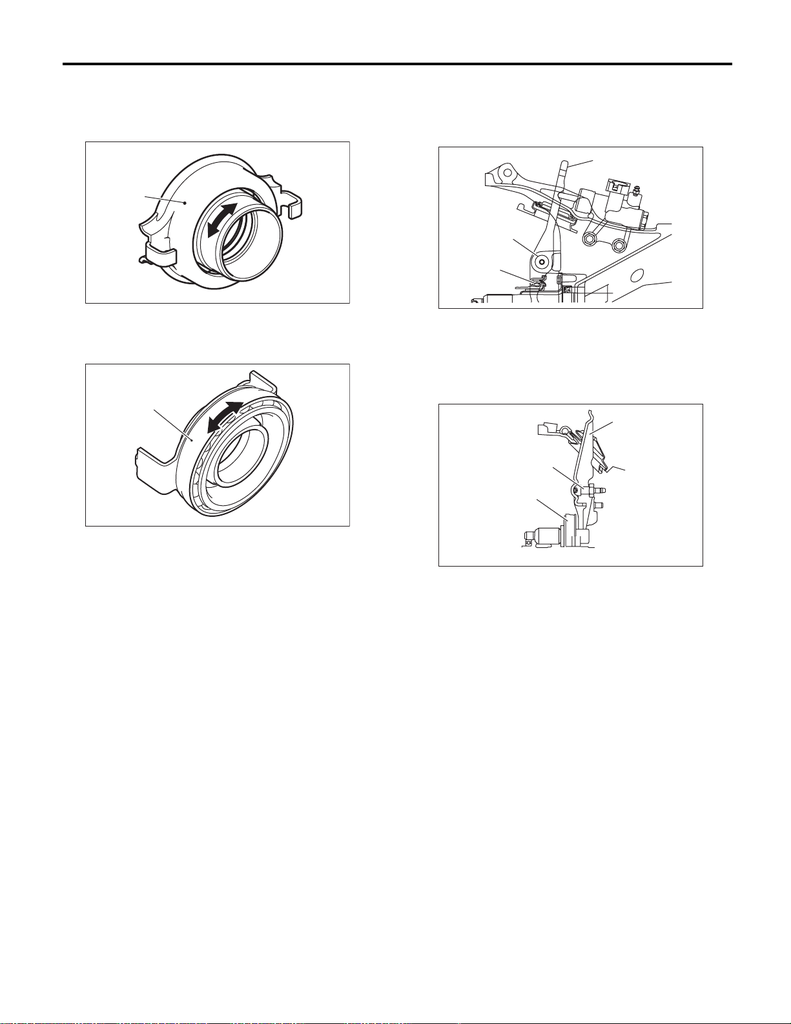

CL-20

Release Bearing and Lever

CLUTCH SYSTEM

2) While applying force to the bearing in the rota-

tional direction, check the bearing for smooth rota-

tion.

• STI model

• Except for STI model

3) Check for wear and damage at the bearing case

surface in contact with the lever.

2. RELEASE LEVER

Check for wear in release shaft contact area and

release bearing case contact area of the lever.

• STI model

• Except for STI model

(A) Bearing case

(A) Bearing case

(A)

CL-00581

CL-00745

(A)

(A) Release lever

(B) Release shaft

(C) Release bearing

(A) Release lever

(B) Pivot

(C) Release bearing

CL-00666

(A)

(B)

(C)

CL-00746

(B)

(C)

(A)